# Problem Set 2^{K-P} Designs

# 1 Quarter Fraction Design

*This problem is adapted from Montgomery (2017) Problem 8.23*

A researcher is conducting an experiment using Monte Carlo simulation of an inventory system. There are five factors: $A$, $B$, $C$, $D$, and $E$ that relate to the design parameters of the system. The response is measured in cost. The researcher could only do 8 runs using $I = ABD = BCE$ as the defining relations. The results by treatment combination name are located here: Montgomery_8_23.csv .

## 1.1 Understand the Design and the Data

1. Write out the alias structure for this design (only up to third order interactions is necessary):

```r
library(tidyverse)
# We can do this manually, but FrF2 is a useful function for this:

myDesign <- FrF2::FrF2(nfactors = 5, # We have 5 factors
                       nruns = 8, # We have a 2^(5-2) = 8 design, so 8 runs
                       generators = c('AB', 'BC'), # Recall the generators for FrF2 are odd, but
                       # correspond to the last P letters of your design, i.e., D = AB, and E = BC
                       randomize = F, # We don't want to randomize the design
                       alias.info = 3 # we want to see up to third order interactions
                       )

attr(myDesign, "design.info")$aliased
```

```
## $legend
## [1] "A=A" "B=B" "C=C" "D=D" "E=E"
##
## $main
## [1] "A=BD=CDE" "B=AD=CE"  "C=BE=ADE" "D=AB=ACE" "E=BC=ACD"
##
## $fi2
## [1] "AC=DE=ABE=BCD" "AE=CD=ABC=BDE"
##
## $fi3
## [1] "ABD=BCE"
```

```r
# Here we can see our alias structure pretty clearly, note that this design is Res III
```

2. What is the resolution of this design?

```
This is a resolution III design as none of the main factors are aliased with each other,
but are aliased with some of the 2nd order factors.
```

3. Join the data given with the design in an appropriate way. (Hint: You may find it helpful to figure a way to write the treatment combination names in the design and then do a join (e.g. `left_join` from dplyr to combine your data and design)).

```r
# Read the data
myData <- read.csv('Montgomery_8_23.csv', header = T, sep = ',')

# Consider our design:
myDesign
```

```
##    A  B  C  D  E
## 1 -1 -1 -1  1  1
## 2  1 -1 -1 -1  1
## 3 -1  1 -1 -1 -1
## 4  1  1 -1  1 -1
## 5 -1 -1  1  1 -1
## 6  1 -1  1 -1 -1
## 7 -1  1  1 -1  1
## 8  1  1  1  1  1
## class=design, type= FrF2.generators
```

```r
# We know that if a column has a positive number in it we use the lower case name of the column
# to codify the treatment combination name.
# In so far as I know, there isn't a useful functio for this, but we can do some dplyr-ing and make TCs:
# Basically we do this as a series of ifelse() functions and pasting with no seeparation
myDesign <- myDesign %>% mutate(TC = ifelse(A == '1', 'a', '')) %>%
  mutate(TC = paste(TC, ifelse(B == '1', 'b', ''), sep = '')) %>%
  mutate(TC = paste(TC, ifelse(C == '1', 'c', ''), sep = '')) %>%
  mutate(TC = paste(TC, ifelse(D == '1', 'd', ''), sep = '')) %>%
  mutate(TC = paste(TC, ifelse(E == '1', 'e', ''), sep = '')) %>%
  mutate(TC = ifelse(TC == '', '(1)', TC))
#We can check our work
myDesign
```

```
##    A  B  C  D  E    TC
## 1 -1 -1 -1  1  1    de
## 2  1 -1 -1 -1  1    ae
## 3 -1  1 -1 -1 -1     b
## 4  1  1 -1  1 -1   abd
## 5 -1 -1  1  1 -1    cd
## 6  1 -1  1 -1 -1    ac
## 7 -1  1  1 -1  1   bce
## 8  1  1  1  1  1 abcde
```

```r
# We can then join our data using left_join
myDF <- left_join(myDesign, myData)
# Note that left_join by default joins on matching column names
# and it will coerce data types to match if it can
myDF
```

```
##    A  B  C  D  E    TC Cost
## 1 -1 -1 -1  1  1    de   95
## 2  1 -1 -1 -1  1    ae  134
## 3 -1  1 -1 -1 -1     b  158
## 4  1  1 -1  1 -1   abd  190
## 5 -1 -1  1  1 -1    cd   92
## 6  1 -1  1 -1 -1    ac  187
## 7 -1  1  1 -1  1   bce  155
## 8  1  1  1  1  1 abcde  185
```

## 1.2 Visualize the Data

1. Visualize the main effects of the data. Comment on what you see.

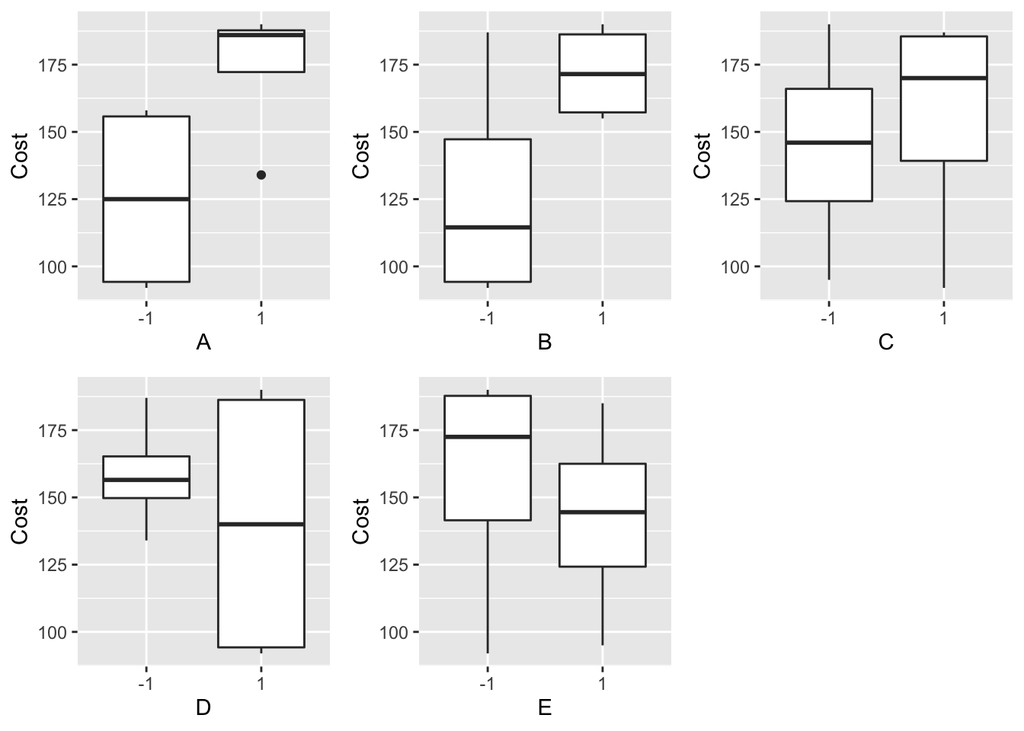

```r
ggpubr::ggarrange(
  ggplot(myDF, aes(x = A, y = Cost)) + geom_boxplot(),
  ggplot(myDF, aes(x = B, y = Cost)) + geom_boxplot(),
  ggplot(myDF, aes(x = C, y = Cost)) + geom_boxplot(),
  ggplot(myDF, aes(x = D, y = Cost)) + geom_boxplot(),
  ggplot(myDF, aes(x = E, y = Cost)) + geom_boxplot()
)
```

```r
# Recall, each of these boxes is just four data points.
# It looks as if A and B are significant, the others may not be.
```

## 1.3 Effects

Estimate the effects of all main factors and any 2nd level interactions that are not aliased with main factors.

```r
# Recall that FrF2 produces levels as factors, not integers
# There may be an easier way to do this, but this works
myDF <- myDF %>%
  mutate(A = as.integer(as.character(A))) %>%
  mutate(B = as.integer(as.character(B))) %>%
  mutate(C = as.integer(as.character(C))) %>%
  mutate(D = as.integer(as.character(D))) %>%
  mutate(E = as.integer(as.character(E)))

Effect.A <- (1/(2^(5-2-1)))*sum(myDF$A * myDF$Cost)
Effect.B <- (1/(2^(5-2-1)))*sum(myDF$B * myDF$Cost)
Effect.C <- (1/(2^(5-2-1)))*sum(myDF$C * myDF$Cost)
Effect.D <- (1/(2^(5-2-1)))*sum(myDF$D * myDF$Cost)
Effect.E <- (1/(2^(5-2-1)))*sum(myDF$E * myDF$Cost)
Effect.AC <- (1/(2^(5-2-1)))*sum(myDF$A * myDF$C * myDF$Cost)
Effect.AE <- (1/(2^(5-2-1)))*sum(myDF$A * myDF$E * myDF$Cost)

Effects <- data.frame(
  Factor.Name = c('A', 'B', 'C', 'D', 'E', 'AC', 'AE'),
  Effect = c(Effect.A, Effect.B, Effect.C, Effect.D, Effect.E, Effect.AC, Effect.AE)
)

Effects
```

```
##   Factor.Name Effect
## 1           A   49.0
## 2           B   45.0
## 3           C   10.5
## 4           D  -18.0
## 5           E  -14.5
## 6          AC   13.5
## 7          AE  -14.5
```

2. Based on this, what factors do you consider significant?

```
It appears that A and B are almost certainly significant.
```

## 1.4 Second Run

You were able to do a second run of 8 factors and got the following results:

```r
second.run <- data.frame(
  TC = c('ade', 'e', 'ab', 'bd', 'acd', 'c', 'abce', 'bcde'),
  Cost = c(136, 93, 187, 153, 139, 99, 191, 150)
)
```

You got this design by using the following generators (i.e., an alternate fraction): $D = -AB$ and $E = BC$.

Combine these results with your previous results:

```r
# We can choose to do this one of two ways.
# The first is that we can generate the design from the above generators as such:
second.design <- FrF2::FrF2(nfactors = 5, nruns = 8, generators = c('-AB', 'BC'), alias.info = 3, randomized = F)
second.design
```

```
##    A  B  C  D  E
## 1 -1 -1  1 -1 -1
## 2 -1  1  1  1  1
## 3  1  1  1 -1  1
## 4  1  1 -1 -1 -1
## 5  1 -1 -1  1  1
## 6 -1  1 -1  1 -1
## 7  1 -1  1  1 -1
## 8 -1 -1 -1 -1  1
## class=design, type= FrF2.generators
```

```r
# We can then proceed in the same manner:
second.design <- second.design %>% mutate(TC = ifelse(A == '1', 'a', '')) %>%
  mutate(TC = paste(TC, ifelse(B == '1', 'b', ''), sep = '')) %>%
  mutate(TC = paste(TC, ifelse(C == '1', 'c', ''), sep = '')) %>%
  mutate(TC = paste(TC, ifelse(D == '1', 'd', ''), sep = '')) %>%
  mutate(TC = paste(TC, ifelse(E == '1', 'e', ''), sep = '')) %>%
  mutate(TC = ifelse(TC == '', '(1)', TC))

# Join the tables
second.DF <- left_join(second.design, second.run)
second.DF <- second.DF %>%
  mutate(A = as.integer(as.character(A))) %>%
  mutate(B = as.integer(as.character(B))) %>%
  mutate(C = as.integer(as.character(C))) %>%
  mutate(D = as.integer(as.character(D))) %>%
  mutate(E = as.integer(as.character(E)))

# Bind the two data frames:
final.design <- rbind(myDF, second.DF)
final.design
```

```
##     A  B  C  D  E    TC Cost
## 1  -1 -1 -1  1  1    de   95
## 2   1 -1 -1 -1  1    ae  134
## 3  -1  1 -1 -1 -1     b  158
## 4   1  1 -1  1 -1   abd  190
## 5  -1 -1  1  1 -1    cd   92
## 6   1 -1  1 -1 -1    ac  187
## 7  -1  1  1 -1  1   bce  155
## 8   1  1  1  1  1 abcde  185
## 9  -1 -1  1 -1 -1     c   99
## 10 -1  1  1  1  1  bcde  150
## 11  1  1  1 -1  1  abce  191
## 12  1  1 -1 -1 -1    ab  187
## 13  1 -1 -1  1  1   ade  136
## 14 -1  1 -1  1 -1    bd  153
## 15  1 -1  1  1 -1   acd  139
## 16 -1 -1 -1 -1  1     e   93
```

```r
# We can then proceed to analyze our data as before.
# The one challenge of this, is our alias structure is not immediately clear

# We can alternatively think about what our two sets of generators told us
# In the first one, take all TCs where D = AB and E = BC
# In the second one, take all TCs where D = -AB and E = BC
# We now have all possibilities for D, so we only have E = BC as a generator
# Let's generate that design

final.design.generated <- FrF2::FrF2(nfactors = 5, nruns = 16, generators = 'BC', randomize = F, alias.info = 3)

# Let's compare with final.design
# First, convert all of A,B, C, D, and E to factors:
final.design <- final.design %>% mutate(A = as.factor(A), B = as.factor(B), C = as.factor(C), D = as.factor(D), E = as.factor(E))
# Second, we can join on the generated design to see if we have every TC
results <- left_join(final.design.generated, final.design)
results
```

```
##     A  B  C  D  E    TC Cost
## 1  -1 -1 -1 -1  1     e   93
## 2   1 -1 -1 -1  1    ae  134
## 3  -1  1 -1 -1 -1     b  158
## 4   1  1 -1 -1 -1    ab  187
## 5  -1 -1  1 -1 -1     c   99
## 6   1 -1  1 -1 -1    ac  187
## 7  -1  1  1 -1  1   bce  155
## 8   1  1  1 -1  1  abce  191
## 9  -1 -1 -1  1  1    de   95
## 10  1 -1 -1  1  1   ade  136
## 11 -1  1 -1  1 -1    bd  153
## 12  1  1 -1  1 -1   abd  190
## 13 -1 -1  1  1 -1    cd   92
## 14  1 -1  1  1 -1   acd  139
## 15 -1  1  1  1  1  bcde  150
## 16  1  1  1  1  1 abcde  185
```

```r
# It looks like this worked and is the correct understanding
# This is convenient, because we now have a design with our alias structure - final.design.generated
# and also a dataframe with all of our data, results, etc.
```